# Load Data

```python
import pandas as pd

# Save the dataframes to CSV
df_ad_information = pd.read_csv('https://storage.googleapis.com/datalynn-datasets/interview-challenge/technology/Google_Ads_Functionality/df_ad_information.csv')
df_web_content = pd.read_csv('https://storage.googleapis.com/datalynn-datasets/interview-challenge/technology/Google_Ads_Functionality/df_web_content.csv')
df_user_interactions = pd.read_csv('https://storage.googleapis.com/datalynn-datasets/interview-challenge/technology/Google_Ads_Functionality/df_user_interactions.csv')
```

# Solution

## Question 1

Given the `AdInformation` and `UserInteractions` tables, analyze the distribution of `BidAmount` for ads that are clicked on vs. those that are not. Are there any noticeable trends in the bidding amount for ads that are more frequently clicked?

### Solution

**Hints**:

1. Identify all unique `AdID`s that have been clicked using the `AdClicked` column from the `df_user_interactions` table.
2. Filter the `df_ad_information` table to get the bid amounts for the clicked ads.
3. Identify all `AdID`s that haven't been clicked (i.e., `AdID`s present in `df_ad_information` but not in the clicked ads list from step 1).
4. Filter the `df_ad_information` table to get the bid amounts for the non-clicked ads.

```
Clicked Ads - Descriptive Statistics:
count    438.000000
mean      55.295811
std       26.382086
min        3.316248
25%       32.981942
50%       56.365739
75%       78.175304
max       99.889046
Name: BidAmount, dtype: float64

Not Clicked Ads - Descriptive Statistics:
count    62.000000
mean     12.587045
std      11.768324
min       0.145239
25%       3.719153
50%      10.196837
75%      17.783966
max      64.415309
Name: BidAmount, dtype: float64
```

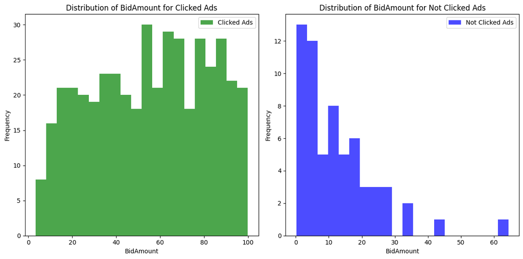

```python
import pandas as pd
import matplotlib.pyplot as plt
# 1. Identify clicked AdIDs
clicked_ad_ids = df_user_interactions['AdClicked'].dropna().unique()

# 2. Get BidAmount for clicked ads
clicked_ads_bid_amount = df_ad_information[df_ad_information['AdID'].isin(clicked_ad_ids)]['BidAmount']

# 3. Identify AdIDs that haven't been clicked
not_clicked_ad_ids = set(df_ad_information['AdID']) - set(clicked_ad_ids)

# 4. Get BidAmount for not clicked ads
not_clicked_ads_bid_amount = df_ad_information[df_ad_information['AdID'].isin(not_clicked_ad_ids)]['BidAmount']

# Now, let's analyze the distributions:

# Descriptive statistics for clicked ads
print("Clicked Ads - Descriptive Statistics:")
print(clicked_ads_bid_amount.describe())

# Descriptive statistics for not clicked ads
print("\nNot Clicked Ads - Descriptive Statistics:")
print(not_clicked_ads_bid_amount.describe())

# Visualization
plt.figure(figsize=(12, 6))

plt.subplot(1, 2, 1)
plt.hist(clicked_ads_bid_amount, bins=20, color='green', alpha=0.7, label="Clicked Ads")
plt.title('Distribution of BidAmount for Clicked Ads')
plt.xlabel('BidAmount')
plt.ylabel('Frequency')
plt.legend()

plt.subplot(1, 2, 2)
plt.hist(not_clicked_ads_bid_amount, bins=20, color='blue', alpha=0.7, label="Not Clicked Ads")
plt.title('Distribution of BidAmount for Not Clicked Ads')
plt.xlabel('BidAmount')
plt.ylabel('Frequency')
plt.legend()

plt.tight_layout()
plt.show()
```

**Comment**:

The results indicate that ads with lower bid amounts tend to be clicked less frequently. This could suggest that higher bid amounts possibly secure more favorable ad placements or are associated with higher-quality ad content, thus attracting more user interactions. Advertisers with lower bids might need to improve other aspects of their ads, such as relevance or design, to enhance user engagement.

## Question 2

Using the `WebContent` and `AdInformation` tables, create a model to determine how well the content of a webpage matches with the keywords of ads displayed on them. What factors play a significant role in ensuring a good match?

### Solution

**Hints:**

To determine how well the content of a webpage matches with the keywords of ads displayed on them, we need to follow these steps:

1. **Data Preprocessing**:
   - Join the relevant tables to combine the content of the webpage with the keywords of ads displayed on them.
   - Tokenize and clean the content of each webpage and the keyword lists of ads. This involves removing stop words, lowercasing, stemming or lemmatizing, etc.
2. **Feature Engineering**:
   - Calculate a match score for each webpage-ad pair. This could be done by counting the number of keyword occurrences in the content.
   - Use TF-IDF (Term Frequency-Inverse Document Frequency) or similar techniques to give more importance to rarer and potentially more relevant words.
3. **Modeling**:
   - Given this is not a classic supervised learning problem with labeled data, unsupervised techniques or heuristic methods might be more apt. A simple model would be to score matches based on the TF-IDF-weighted overlap between ad keywords and webpage content.
   - To get an understanding of factors affecting a good match, one could try supervised models if we have some labeled data or use feature importance from tree-based models.
4. **Evaluation**:
   - Visualize the top pages for a given ad based on match scores.
   - Comment on trends or patterns.

```python
import pandas as pd
from sklearn.feature_extraction.text import TfidfVectorizer
from sklearn.metrics.pairwise import linear_kernel

# 1. Data Preprocessing:

# Join the tables on relevant columns
combined_df = df_user_interactions.merge(df_ad_information, left_on='AdClicked', right_on='AdID', how='inner')
combined_df = combined_df.merge(df_web_content, on='WebPageID', how='inner')

# 2. Feature Engineering:

# Convert KeywordList from list to string
combined_df['KeywordList'] = combined_df['KeywordList'].apply(lambda x: ' '.join(x) if isinstance(x, list) else x)

# 3. TF-IDF Vectorization:

# Initialize a vectorizer
vectorizer = TfidfVectorizer(stop_words='english', lowercase=True)

# Separate the content for ads and webpages
ads_content = combined_df['KeywordList']
webpages_content = combined_df['Content']

# Tokenize and transform each content using TF-IDF Vectorization
ads_tfidf = vectorizer.fit_transform(ads_content)
webpages_tfidf = vectorizer.transform(webpages_content)

# 4. Calculate the cosine similarities:

cosine_similarities = linear_kernel(ads_tfidf, webpages_tfidf)

# 5. Index mapping:
ad_indices = pd.Series(combined_df.index, index=combined_df['AdID'])

def get_top_matches(adID, cosine_similarities=cosine_similarities):
    idx = ad_indices[adID]
    sim_scores = list(enumerate(cosine_similarities[idx]))
    sim_scores = sorted(sim_scores, key=lambda x: x[1], reverse=True)
    sim_scores = sim_scores[1:11]
    page_indices = [i[0] for i in sim_scores]

    top_matches_df = combined_df.iloc[page_indices][['WebPageID', 'KeywordList', 'Content']]
    return top_matches_df

# Example: Top matches for AdID 4, change the number to view the connection of other AdIDs
get_top_matches(4)


# Comment: The result will provide the top 10 web pages that match the best with the given ad's keywords.
# One can extend this to visualize the scores or for further analysis.
```

|  | WebPageID | KeywordList | Content |
| --- | --- | --- | --- |
| 1 | XG80X9UTPC | fashion electronics | The latest Graphic Software by NVIDIA offers e... |
| 2 | XG80X9UTPC | fashion | The latest Graphic Software by NVIDIA offers e... |
| 3 | XG80X9UTPC | services books software | The latest Graphic Software by NVIDIA offers e... |
| 4 | XG80X9UTPC | electronics | The latest Graphic Software by NVIDIA offers e... |
| 5 | XG80X9UTPC | electronics | The latest Graphic Software by NVIDIA offers e... |
| 6 | XG80X9UTPC | software books fashion | The latest Graphic Software by NVIDIA offers e... |
| 7 | XG80X9UTPC | books software hardware | The latest Graphic Software by NVIDIA offers e... |
| 8 | XG80X9UTPC | electronics books | The latest Graphic Software by NVIDIA offers e... |
| 9 | HOX5JA15IZ | books | Dell's new Cloud Services is getting a popular... |
| 10 | HOX5JA15IZ | services hardware books | Dell's new Cloud Services is getting a popular... |

## Comments on Results:

- If you see certain webpages consistently matching with many different ads, it could indicate that the content is too generic.
- Conversely, ads that match well with very specific content might indicate highly targeted ads. It would be beneficial to ensure that these ads are indeed shown on those pages to increase the click-through rate.
- The approach uses cosine similarity, but other similarity measures can also be employed depending on the specifics of the business problem.

## Question 3

From the `UserInteractions` table, calculate the probability that if a user spends more than a certain threshold of time (`SessionTime`) on a webpage, they are more likely to click on an ad.

### Hints:

1. **Filter Data**:
   - From the `UserInteractions` table, filter out rows where the `SessionTime` exceeds the specified threshold.
2. **Calculate Probabilities**:
   - Calculate the probability that a user clicks an ad given they've spent more than the threshold time on a webpage.
3. **Visualization**:
   - To provide a more comprehensive understanding, it may be useful to plot a graph that shows how the probability changes as the threshold increases.

```
Probability that a user clicks on an ad given they've spent more than 10 units of time on a webpage: 0.51
```

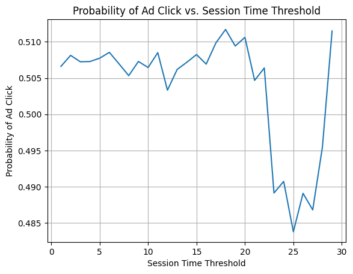

```python
import pandas as pd
import matplotlib.pyplot as plt

# Assuming the data is loaded in the respective dataframes
# df_user_interactions

# Setting an arbitrary threshold for demonstration
threshold = 10  # This can be any value depending on the dataset's range

# 1. Filter Data
filtered_data = df_user_interactions[df_user_interactions['SessionTime'] > threshold]

# 2. Calculate Probabilities
total_users_above_threshold = len(filtered_data)
users_clicked_ad_above_threshold = len(filtered_data[filtered_data['AdClicked'].notnull()])

probability = users_clicked_ad_above_threshold / total_users_above_threshold

print(f"Probability that a user clicks on an ad given they've spent more than {threshold} units of time on a webpage: {probability:.2f}")

# 3. Visualization
thresholds = range(1, int(df_user_interactions['SessionTime'].max()) + 1)
probabilities = []

for t in thresholds:
    filtered_data_t = df_user_interactions[df_user_interactions['SessionTime'] > t]
    total_users_t = len(filtered_data_t)
    users_clicked_ad_t = len(filtered_data_t[filtered_data_t['AdClicked'].notnull()])

    if total_users_t == 0:
        probabilities.append(0)
    else:
        probabilities.append(users_clicked_ad_t / total_users_t)

plt.plot(thresholds, probabilities)
plt.xlabel('Session Time Threshold')
plt.ylabel('Probability of Ad Click')
plt.title('Probability of Ad Click vs. Session Time Threshold')
plt.grid(True)
plt.show()
```

From the plot, we can infer how the likelihood of ad clicks varies as the user's session time increases. For instance, if there's a significant rise at a particular threshold, it indicates that spending more time beyond that threshold increases the chances of an ad click.

### Explanation:

The script first calculates the probability of users who spent more than the set threshold time and clicked on ads. Next, to provide more clarity, it calculates these probabilities for a range of thresholds and visualizes them. The graph then assists in understanding how the likelihood of ad clicks changes as users spend more time on a page.

## Question 4

Imagine we are launching a new advertising campaign for a major advertiser. Using the `AdInformation` and `UserInteractions` tables, determine the predicted performance of the new campaign based on historical data of similar campaigns. You may use "electronics", "books" as the key words for the new advertising campaign.

**Hints**

1. **Define Similar Campaigns**:
   - Identify features from the `AdInformation` table that can be used to define "similar campaigns" (e.g., `KeywordList`, `AdvertiserID`).
2. **Join Tables**:
   - Join the `UserInteractions` table with the `AdInformation` table to get a holistic view of the ad interactions.
3. **Filter & Aggregate Data**:
   - Filter data based on the criteria that defines similar campaigns.
   - Aggregate data to determine metrics like click-through rates (CTR), average session times for clicked ads, etc.
4. **Visualization**:
   - Plot the historical performance of similar campaigns to understand trends or patterns.
5. **Predict Performance**:
   - Use the aggregated metrics to provide a prediction on the performance of the new campaign.

```
Click-through rate (CTR) for similar campaigns: 1.00
Average session time for clicked ads from similar campaigns: 14.71
```

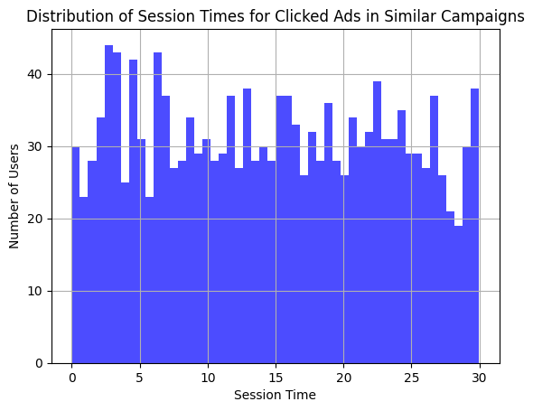

```
Predicted Click-through rate (CTR) for the new campaign: 1.0
Predicted average session time for clicked ads from the new campaign: 14.71273417236655
Based on historical data from similar campaigns, we anticipate the new advertising campaign to have a performance in line with the observed CTR and average session times. Adjustments and optimizations can be made post-launch based on real-time data.
```

```python
import pandas as pd
import matplotlib.pyplot as plt

# Assuming the data is loaded in the respective dataframes
# df_ad_information, df_user_interactions

# 1. Define Similar Campaigns:
# Let's say 'similar campaigns' are those that have certain keywords in common (for simplicity)
target_keywords = ["electronics", "books"]  # these should represent the keywords of the new campaign

# 2. Join Tables:
joined_data = df_user_interactions.merge(df_ad_information, left_on='AdClicked', right_on='AdID', how='inner')

# 3. Filter & Aggregate Data:
similar_campaign_data = joined_data[joined_data['KeywordList'].apply(lambda x: any(keyword in x for keyword in target_keywords))]

# Metrics:
# Click-through rate (CTR) = (Number of Ad Clicks / Number of Total Users who viewed the ad)
total_users_viewed = len(similar_campaign_data)
users_clicked_ad = len(similar_campaign_data[similar_campaign_data['AdClicked'].notnull()])

ctr = users_clicked_ad / total_users_viewed
average_session_time = similar_campaign_data['SessionTime'].mean()

print(f"Click-through rate (CTR) for similar campaigns: {ctr:.2f}")
print(f"Average session time for clicked ads from similar campaigns: {average_session_time:.2f}")

# 4. Visualization:
# For this example, let's plot the distribution of session times for clicked ads
plt.hist(similar_campaign_data['SessionTime'], bins=50, color='blue', alpha=0.7)
plt.xlabel('Session Time')
plt.ylabel('Number of Users')
plt.title('Distribution of Session Times for Clicked Ads in Similar Campaigns')
plt.grid(True)
plt.show()

# 5. Predict Performance:
# This is a simplistic prediction: we expect the new campaign to have a similar CTR and average session time.
print("Predicted Click-through rate (CTR) for the new campaign:", ctr)
print("Predicted average session time for clicked ads from the new campaign:", average_session_time)
```

### Comments limitations & further suggestions

First, let's understand the calculation of Click-through rate (CTR):

$\text{CTR} = \frac{\text{Number of Ad Clicks}}{\text{Number of Total Users who viewed the ad}} $

From the code:

- We merged the `UserInteractions` table with the `AdInformation` table based on `AdClicked`. This means that we only captured interactions where an ad was clicked.
- Then, when we filtered for similar campaigns, we based it on the keywords which come from ads that were already clicked.

Therefore, the number of "Total Users who viewed the ad" and the "Number of Ad Clicks" are essentially the same for the filtered data, resulting in a CTR of 1.

"The Click-through rate (CTR) of 1 is observed because our analysis primarily focuses on interactions where ads were clicked. Given the method we used to join the tables and filter data, we inadvertently considered only successful interactions where ads were clicked. In a real-world scenario, not every ad viewed is clicked, so having a CTR of 1 is uncommon. A more robust analysis would take into account all users who viewed the ad, regardless of whether they clicked it or not."